# Polygenic contributions to face-sensitive cortical responses in infants with a family history of autism

AnnaGui

29/01/2021

# Statistical analyses

### Load packages

```r
library(plyr)
library(ggplot2)
library(car)
library(dplyr)
library(ggpubr)
```

### Load files

set:

- WORKDIR=path to working directory
- PHENOFILE=path to phenotype csv file
- IDMATCHFILE=path to file for matching genetic and EEG IDs
- PGSFILE_Aut=path to txt file with all thresholded polygenic scores
- PGSFILE_xDx=path to txt file with all thresholded polygenic scores

Phenotype and ID files

```r
setwd(WORKDIR)
dataset<-read.csv(PHENOFILE)

ID_corr<-read.csv(IDMATCHFILE, header=T)
names(ID_corr)<-c("Family_ID","Genetic_ID","Phase_ID","tissue")
```

Merge with Autism polygenic score (PGS) file (PT=0.01)

```r
PRS_Aut<-read.table(PGSFILE_Aut, header=T)
PRS_Aut_id<-merge(ID_corr,PRS_Aut,by.x=c('Genetic_ID','Family_ID'), by.y=c('IID','FID'), all.y=T)
PRS_Aut_id$Phase_ID<-as.character(PRS_Aut_id$Phase_ID)

ds_prs_Aut<-merge(dataset, PRS_Aut_id[,c("Phase_ID","tissue","X0.01")], by.x='ID', by.y='Phase_ID',all = F)
ds_prs_Aut<-ds_prs_Aut[complete.cases(ds_prs_Aut$X0.01)&complete.cases(ds_prs_Aut$fn_n290_lat),]
```

Merge with xDx PGS (PT=0.5)

```r
PRS_xDx<-read.table(PGSFILE_xDx, header=T)
PRS_xDx_id<-merge(ID_corr,PRS_xDx,by.x=c('Genetic_ID','Family_ID'), by.y=c('IID','FID'), all.y=T)
PRS_xDx_id$Phase_ID<-as.character(PRS_xDx_id$Phase_ID)

ds_prs<-merge(ds_prs_Aut, PRS_xDx_id[,c("Phase_ID","X0.5")], by.x='ID', by.y='Phase_ID',all = F)
```

### Obtain summary info for N=104 infants with complete data

*For entire sample:*

`ddply(ds_prs, "sex", summarise, N= length(unique(ID)))`

`mean(ds_prs_Aut$M_CA_8, na.rm = T)`

`sd(ds_prs$M_CA_8, na.rm = T)`

`mean(ds_prs$fn_n290_lat)`

`sd(ds_prs$fn_n290_lat)`

`mean(ds_prs$X0.01)`

`sd(ds_prs$X0.01)`

`mean(ds_prs$X0.5)`

`sd(ds_prs$X0.5)`

*By group:*

`ddply(ds_prs, c("sex","Group"), summarise, N= length(unique(ID)))`

`ddply(ds_prs, "Group", summarise, mean(M_CA_8, na.rm = T), sd(M_CA_8, na.rm = T))`

`ddply(ds_prs, "Group", summarise, mean(fn_n290_lat), sd(fn_n290_lat))`

`ddply(ds_prs, "Group", summarise, mean(X0.01), sd(X0.01))`

`ddply(ds_prs, "Group", summarise, mean(X0.5), sd(X0.5))`

### ANOVAs:

- Age by Group

check assumptions

`ds_prs$Group<-as.factor(ds_prs$Group)`

`leveneTest(ds_prs$M_CA_8~ds_prs$Group)`

`shapiro.test(ds_prs[ds_prs$Group=='0',]$M_CA_8)`

`shapiro.test(ds_prs[ds_prs$Group=='1',]$M_CA_8)`

`shapiro.test(ds_prs[ds_prs$Group=='2',]$M_CA_8)`

`shapiro.test(ds_prs[ds_prs$Group=='3',]$M_CA_8)`

ANOVA

`summary(aov(M_CA_8~Group, data=ds_prs))`

post-hoc

`TukeyHSD(aov(M_CA_8~Group, data=ds_prs))`

- F-N N290 latency by Group

assumptions

`leveneTest(ds_prs$fn_n290_lat~ds_prs$Group)`

`shapiro.test(ds_prs[ds_prs$Group=='0',]$fn_n290_lat)`

`shapiro.test(ds_prs[ds_prs$Group=='1',]$fn_n290_lat)`

`shapiro.test(ds_prs[ds_prs$Group=='2',]$fn_n290_lat)`

`shapiro.test(ds_prs[ds_prs$Group=='3',]$fn_n290_lat)`

ANOVA

`summary(aov(fn_n290_lat~Group, data=ds_prs))`

post-hoc

`TukeyHSD(aov(fn_n290_lat~Group, data=ds_prs))`

check with analyses by Familial History (noFH vs FH) and then by Outcome (FH-TD vs FH-Other vs FH-Aut)

`summary(aov(ds_prs$fn_n290_lat~ds_prs$FH))` `summary(aov(ds_prs[ds_prs$Group!='0',]$fn_n290_lat~as.factor(ds_prs[ds_prs$Group!='0',]$Group)))`

check with covariates:

`summary(aov(fn_n290_lat~Group + sex + Phase + M_CA_8, data=ds_prs))`

Plot F-N N290 latency by Group

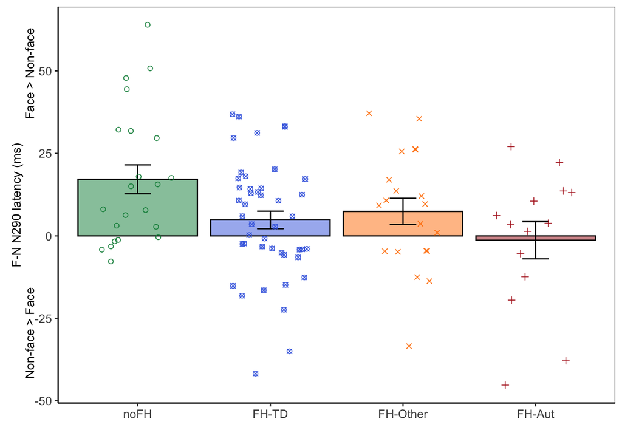

```r
ds_prs_plot<-ds_prs[complete.cases(ds_prs$Group),]
ds_prs_plot$Group<-as.factor(ds_prs_plot$Group)
ds_prs_plot$Group<-droplevels(ds_prs_plot$Group)

#jpeg(file="N290_byGroup.jpeg",width = 5, height = 5, units = 'in', res = 300)
N290_byGroup<-ggplot(ds_prs_plot, aes(x=Group, y=fn_n290_lat, colour=Group, fill=Group, shape=Group)) +
  geom_bar(position =position_dodge(.9), stat = 'summary', fun = 'mean', color="black",alpha = 0.5) +
  geom_errorbar(stat = 'summary', position = position_dodge(.9), width=.2, color="black" ) +
  geom_jitter( aes(x=Group, y=fn_n290_lat, shape=Group), position=position_jitter(width=0.3, height=0.2), alpha=0.9) +
  ylab("F-N N290 latency (ms)\n Non-face > Face                                                 Face > Non-face") +
  xlab("") +
  scale_x_discrete(breaks=c("0", "1", "2","3"),labels=c("noFH", "FH-TD", "FH-Other","FH-Aut")) +
  scale_shape_manual(values=c("0"=1, "1"=13,"2"= 4,"3"=3), name=" ", labels=c("noFH", "FH-TD", "FH-Other","FH-Aut")) +
  scale_fill_manual(values=c("0"='springgreen4', "1"='royalblue',"2"= 'darkorange1',"3"='firebrick'), name=" ", labels=c("noFH", "FH-TD", "FH-Other","FH-Aut")) +
  scale_color_manual(values=c("0"='springgreen4', "1"='royalblue',"2"= 'darkorange1',"3"='firebrick'), name=" ", labels=c("noFH", "FH-TD", "FH-Other","FH-Aut")) +
   theme_bw() +
  theme(axis.title.y = element_text(vjust=-1, size=10, hjust=0.5), axis.line = element_line(colour = "black"), text = element_text(size=12),  panel.grid.major = element_blank(), panel.grid.minor = element_blank()) + guides(fill=F, color=F, shape=F)
print(N290_byGroup)
```

```r
#dev.off()
```

- Autism PGS (PT=0.01) by Group

assumptions

`leveneTest(ds_prs$X0.01~as.factor(ds_prs$Group))`

`shapiro.test(ds_prs[ds_prs$Group=='0',]$X0.01)`

`shapiro.test(ds_prs[ds_prs$Group=='1',]$X0.01)`

`shapiro.test(ds_prs[ds_prs$Group=='2',]$X0.01)`

`shapiro.test(ds_prs[ds_prs$Group=='3',]$X0.01)`

ANOVA

`summary(aov(ds_prs$X0.01~as.factor(ds_prs$Group)))`

post-hoc

`TukeyHSD(aov(ds_prs$X0.01~as.factor(ds_prs$Group)))`

check with analyses by Familial History (noFH vs FH) and then by Outcome (FH-TD vs FH-Other vs FH-Aut)

`summary(aov(ds_prs$X0.01~as.factor(ds_prs$FH)))`

`summary(aov(ds_prs[ds_prs$Group!='0',]$X0.01~as.factor(ds_prs[ds_prs$Group!='0',]$Group)))`

check results with covariates

`summary(aov(X0.01~Group + sex + Phase + M_CA_8 + tissue, data=ds_prs))`

Plot Autism PGS by Group

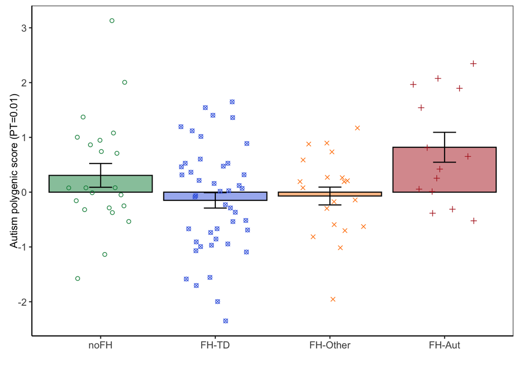

```r
#jpeg(file="ASD_byGroup.jpeg",width = 5, height = 5, units = 'in', res = 300)
ASD_byGroup<-ggplot(ds_prs_plot, aes(x=Group, y=X0.01, colour=Group, fill=Group, shape=Group)) +
  geom_bar(position =position_dodge(.9), stat = 'summary', fun = 'mean', color="black",alpha = 0.5) +
  geom_errorbar(stat = 'summary', position = position_dodge(.9), width=.2, color="black" ) +
  geom_jitter( aes(x=Group, y=X0.01, shape=Group), position=position_jitter(width=0.3, height=0.2), alpha=0.9) +
  ylab("Autism polygenic score (PT=0.01)") +
  xlab("") +
  scale_x_discrete(breaks=c("0", "1", "2","3"),labels=c("noFH", "FH-TD", "FH-Other","FH-Aut")) +
  scale_shape_manual(values=c("0"=1, "1"=13,"2"= 4,"3"=3), name=" ", labels=c("noFH", "FH-TD", "FH-Other","FH-Aut")) +
  scale_fill_manual(values=c("0"='springgreen4', "1"='royalblue',"2"= 'darkorange1',"3"='firebrick'), name=" ", labels=c("noFH", "FH-TD", "FH-Other","FH-Aut")) +
  scale_color_manual(values=c("0"='springgreen4', "1"='royalblue',"2"= 'darkorange1',"3"='firebrick'), name=" ", labels=c("noFH", "FH-TD", "FH-Other","FH-Aut")) +
  theme_bw() +
  theme(axis.title.y = element_text(vjust=-1, size=10, hjust=0.5), axis.line = element_line(colour = "black"), text = element_text(size=12),  panel.grid.major = element_blank(), panel.grid.minor = element_blank()) + guides(fill=F, color=F, shape=F)
print(ASD_byGroup)
```

```r
#dev.off()
```

- xDx PGS (PT=0.5) by Group

assumptions

`leveneTest(ds_prs$X0.5~as.factor(ds_prs$Group))`

`shapiro.test(ds_prs[ds_prs$Group=='0',]$X0.5)`

`shapiro.test(ds_prs[ds_prs$Group=='1',]$X0.5)`

`shapiro.test(ds_prs[ds_prs$Group=='2',]$X0.5)`

`shapiro.test(ds_prs[ds_prs$Group=='3',]$X0.5)`

ANOVA

`summary(aov(ds_prs$X0.5~as.factor(ds_prs$Group)))`

post-hoc

`TukeyHSD(aov(ds_prs$X0.5~as.factor(ds_prs$Group)))`

check with analyses by Familial History (noFH vs FH) and then by Outcome (FH-TD vs FH-Other vs FH-Aut)

`summary(aov(ds_prs$X0.5~as.factor(ds_prs$FH)))`

`summary(aov(ds_prs[ds_prs$Group!='0',]$X0.5~as.factor(ds_prs[ds_prs$Group!='0',]$Group)))`

check results with covariates

`summary(aov(X0.5~Group + sex + Phase + M_CA_8 + tissue, data=ds_prs))`

Plot xDx PGS by Group

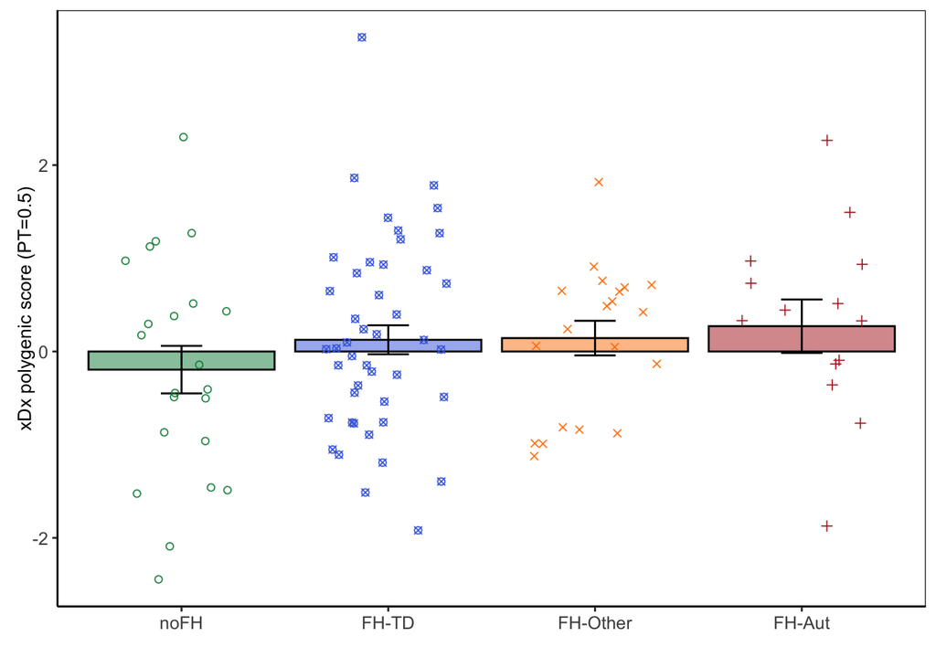

```r
#jpeg(file="xDx_byGroup.jpeg",width = 5, height = 5, units = 'in', res = 300)
xDx_byGroup<-ggplot(ds_prs_plot, aes(x=Group, y=X0.5, colour=Group, fill=Group, shape=Group)) +
  geom_bar(position =position_dodge(.9), stat = 'summary', fun = 'mean', color="black",alpha = 0.5) +
  geom_errorbar(stat = 'summary', position = position_dodge(.9), width=.2, color="black" ) +
  geom_jitter( aes(x=Group, y=X0.5, shape=Group), position=position_jitter(width=0.3, height=0.2), alpha=0.9) +
  ylab("xDx polygenic score (PT=0.5)") +
  xlab("") +
  scale_x_discrete(breaks=c("0", "1", "2","3"),labels=c("noFH", "FH-TD", "FH-Other","FH-Aut")) +
  scale_shape_manual(values=c("0"=1, "1"=13,"2"= 4,"3"=3), name=" ", labels=c("noFH", "FH-TD", "FH-Other","FH-Aut")) +
  scale_fill_manual(values=c("0"='springgreen4', "1"='royalblue',"2"= 'darkorange1',"3"='firebrick'), name=" ", labels=c("noFH", "FH-TD", "FH-Other","FH-Aut")) +
  scale_color_manual(values=c("0"='springgreen4', "1"='royalblue',"2"= 'darkorange1',"3"='firebrick'), name=" ", labels=c("noFH", "FH-TD", "FH-Other","FH-Aut")) +
  theme_bw() +
  theme(axis.title.y = element_text(vjust=-1, size=10, hjust=0.5), axis.line = element_line(colour = "black"), text = element_text(size=12),  panel.grid.major = element_blank(), panel.grid.minor = element_blank()) + guides(fill=F, color=F, shape=F)
print(xDx_byGroup)
```

```r
dev.off()
```

### Regressions

- F-N N290 latency ~ Autism PGS (PT=0.01)

linear regression with PGS more predictive of Autism

`summary(lm(fn_n290_lat~X0.01, data=ds_prs))`

check correlation

`cor.test(ds_prs$fn_n290_lat,ds_prs$X0.01)`

check results with covariates

`summary(lm(fn_n290_lat~X0.01+ sex + Phase + M_CA_8 + tissue, data=ds_prs))`

Plot N290 ~ Autism PGS

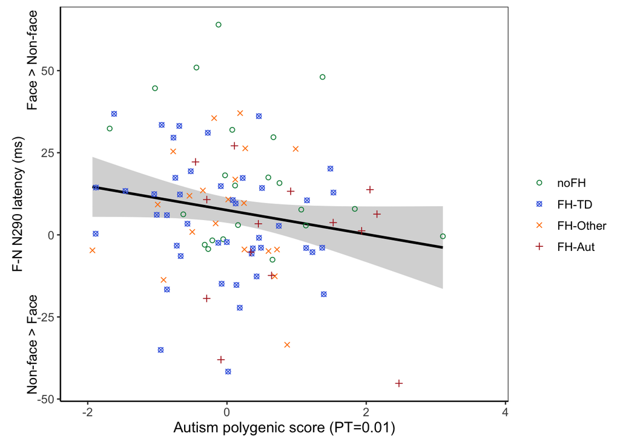

```r
#jpeg(file="N290_ASDpgs.jpeg",width = 7, height = 5, units = 'in', res = 300)
N290_ASDpgs<-ggplot(data=ds_prs_plot, aes(x=X0.01, y=fn_n290_lat)) +
  ylab("F-N N290 latency (ms)\n Non-face > Face                                                 Face > Non-face") +
  xlab("Autism polygenic score (PT=0.01)") +
  xlim(-2.1,3.75)+
  geom_smooth(method = "lm", se = T, color="black") +
  geom_point(aes(color=as.factor(Group), shape=as.factor(Group))) +
  scale_color_manual(values=c("0"='springgreen4', "1"='royalblue',"2"= 'darkorange1',"3"='firebrick'), name="", labels=c("noFH", "FH-TD", "FH-Other","FH-Aut")) +
  scale_shape_manual(values=c("0"=1, "1"=13,"2"= 4,"3"=3), name="", labels=c("noFH", "FH-TD", "FH-Other","FH-Aut")) +
  theme_bw() +
  theme(axis.title.y = element_text(vjust=-1, size=11, hjust=0.5), plot.title = element_text(hjust = 0.5,size=12), axis.line = element_line(colour = "black"), text = element_text(size=12),  panel.grid.major = element_blank(), panel.grid.minor = element_blank())
print(N290_ASDpgs)
```

```r
#dev.off()
```

- F-N N290 latency ~ xDx PGS (PT=0.5)

linear regression with PGS more predictive of atypical development (FH-Other + FH-Aut)

`summary(lm(fn_n290_lat~X0.5, data=ds_prs))`

check correlations

`cor.test(ds_prs$fn_n290_lat,ds_prs$X0.5)`

check results with covariates

`summary(lm(fn_n290_lat~X0.5+ sex + Phase + M_CA_8 + tissue, data=ds_prs))`

Plot N290 ~ xDx PGS

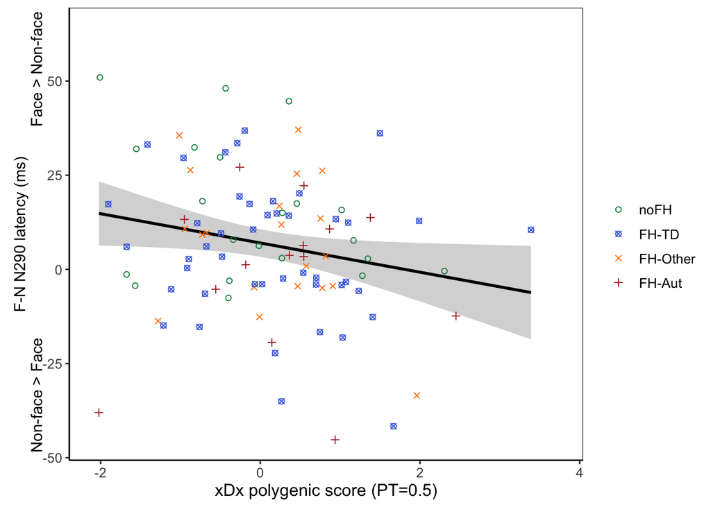

```r
#jpeg(file="N290_xDxpgs.jpeg",width = 7, height = 5, units = 'in', res = 300)
N290_xDxpgs<-ggplot(data=ds_prs_plot, aes(x=X0.5, y=fn_n290_lat)) +
  ylab("F-N N290 latency (ms)\n Non-face > Face                                                 Face > Non-face") +
  xlab("xDx polygenic score (PT=0.5)") +
  xlim(-2.1,3.75)+
  geom_smooth(method = "lm", se = T, color="black") +
  geom_point(aes(color=as.factor(Group), shape=as.factor(Group))) +
  scale_color_manual(values=c("0"='springgreen4', "1"='royalblue',"2"= 'darkorange1',"3"='firebrick'), name="", labels=c("noFH", "FH-TD", "FH-Other","FH-Aut")) +
  scale_shape_manual(values=c("0"=1, "1"=13,"2"= 4,"3"=3), name="", labels=c("noFH", "FH-TD", "FH-Other","FH-Aut")) +
  theme_bw() +
  theme(axis.title.y = element_text(vjust=-1, size=11, hjust=0.5), plot.title = element_text(hjust = 0.5,size=12), axis.line = element_line(colour = "black"), text = element_text(size=12),  panel.grid.major = element_blank(), panel.grid.minor = element_blank())
print(N290_xDxpgs)
```

```r
#dev.off()
```

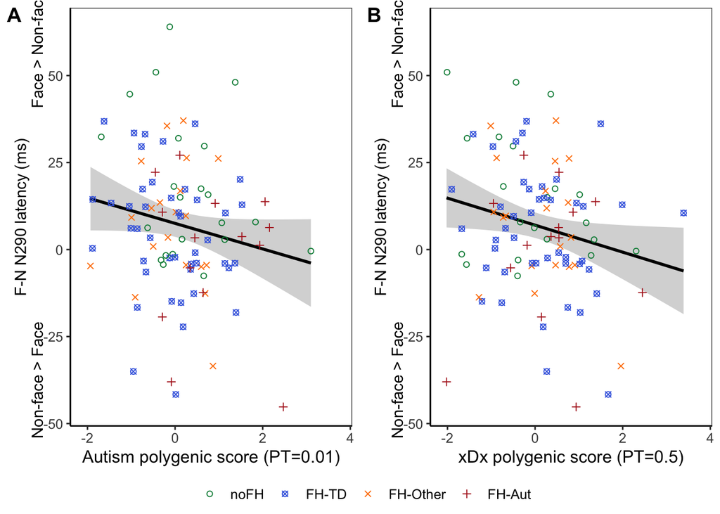

Figure 1

```r
#jpeg('Figure1.jpg', units='in', width=12, height = 6, res = 300)
Figure1<-ggarrange(N290_ASDpgs, N290_xDxpgs, labels = c("A", "B"),
                            ncol = 2, nrow = 1,
                            common.legend = TRUE, legend = "bottom")
print(Figure1)
```

```r
#dev.off()
```